# Murder Data

Sonia Baron, Elise Gonzalez, Zim Oulette

March 26, 2018

# Introduction.

The current project is an analysis of five selected cities across the years. These cities were selected based on a follow-up article of our original FiveThirtyEight data. Published in july 2017, this article provided the cities with the highest and the lowest changes from 2016 to mid-year 2017. We wondered whether these cities presented a sudder change, or if they were slowly changing into such results.

In a follow up article, the murder rates from 2017 across the US are compared to the murder rates from the 1990s. The article explains that while the murder rates have seen an overall increase over the past few years (since 2014), they are not nearly as high as in the 1990s. Another interesting point that was made is that there is evidence that shows that when a city’s murder rate increases, the national average of murder rates seems to counteract or account for this by showing a decrease.

## Load data sets

```r
# Data sets from FiveThirtyEight
murder15A <- read.csv("https://raw.githubusercontent.com/fivethirtyeight/data/master/murder_2016/murder_2015_final.csv")
murder16A <- read.csv("https://raw.githubusercontent.com/fivethirtyeight/data/master/murder_2016/murder_2016_prelim.csv")

#A items are the uncleaned versions, murder15 and murder16, etc. are cleaned.
murder15 <- subset(murder15A, select = -c(change))
head(murder15)
```

```
##         city     state X2014_murders X2015_murders
## 1  Baltimore  Maryland           211           344
## 2    Chicago  Illinois           411           478
## 3    Houston     Texas           242           303
## 4  Cleveland      Ohio            63           120
## 5 Washington      D.C.           105           162
## 6  Milwaukee Wisconsin            90           145
```

```r
murder16 <- subset(murder16A, select = -c(source,as_of,change))
head(murder16)
```

```
##          city     state X2015_murders X2016_murders
## 1     Chicago  Illinois           378           536
## 2     Orlando   Florida            19            73
## 3     Memphis Tennessee           114           158
## 4     Phoenix   Arizona            72           111
## 5   Las Vegas    Nevada            90           125
## 6 San Antonio     Texas            78           111
```

```r
# Last dates data for 2016 was collected
muder16Dates <- subset(murder16A, select = -c(source,change))

# need to organize these two by state
?arrange
```

```
## starting httpd help server ... done
```

```r
murder15 <- murder15 %>%
    arrange(murder15$state)

murder16 <- murder16 %>%
   arrange(murder16$state)
```

```r
#FBI Data
  # loading cleaned data for FBI crime reports

FBI2000 <- read.csv("https://raw.githubusercontent.com/Data-Science-Team-Murder/FauDataSci4real/master/FBI2000.csv")
FBI2005 <- read.csv("https://raw.githubusercontent.com/Data-Science-Team-Murder/FauDataSci4real/master/FBI2005.csv")
FBI2010 <- read.csv("https://raw.githubusercontent.com/Data-Science-Team-Murder/FauDataSci4real/master/FBI2010.csv")
FBI2015 <- read.csv("https://raw.githubusercontent.com/Data-Science-Team-Murder/FauDataSci4real/master/FBI2015.csv")
FBI2016 <- read.csv("https://raw.githubusercontent.com/Data-Science-Team-Murder/FauDataSci4real/master/FBI2016.csv")
```

# Understanding the FiveThirtyEight Data

We run a multiple linear regression matrix to get a better sense of the data

```r
data(murder15)
```

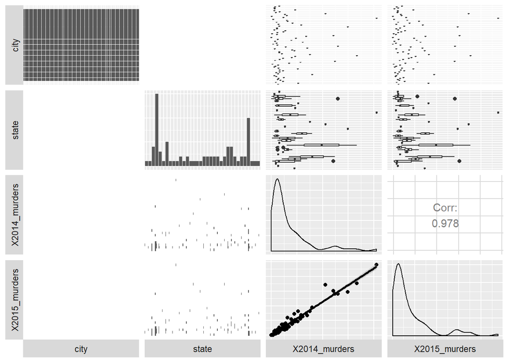

```r
ggpairs (murder15,
        lower = list(
            continuous = "smooth"),
        axisLabels ="none",
        switch = 'both',
        cardinality_threshold = 100)
```

```r
data(murder16)
```

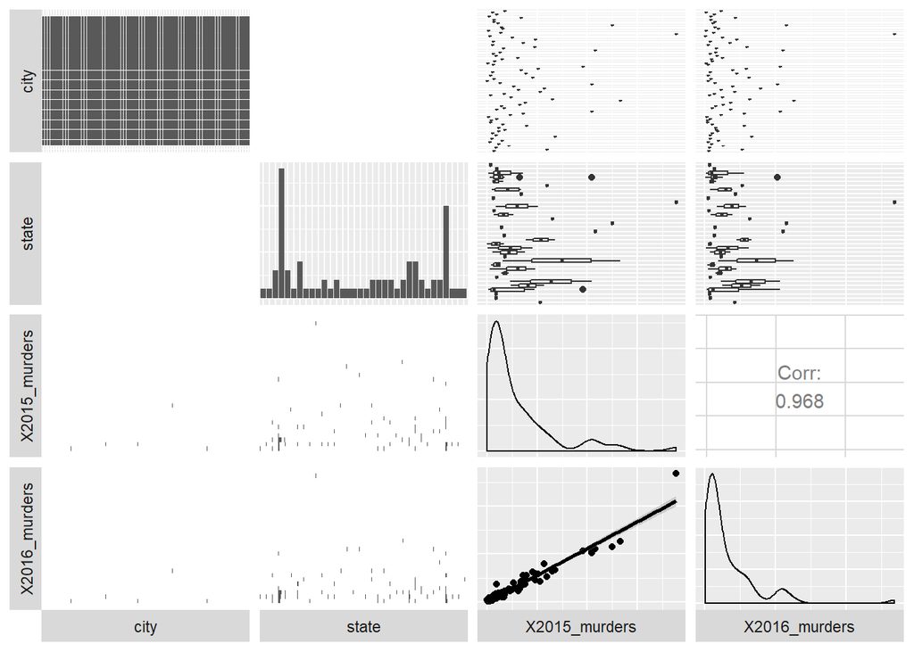

```r
#str(murder15)

ggpairs (murder16,
        lower = list(
            continuous = "smooth"),
        axisLabels ="none",
        switch = 'both',
        cardinality_threshold = 100)
```

```r
FBI2016$STATE
```

```
##  [1] ALABAMA              ALASKA               ARIZONA
##  [4] ARKANSAS             CALIFORNIA           COLORADO
##  [7] CONNECTICUT          DELAWARE             DISTRICT OF COLUMBIA
## [10] GEORGIA              HAWAII               IDAHO
## [13] ILLINOIS             INDIANA              IOWA
## [16] KANSAS               KENTUCKY             LOUISIANA
## [19] MAINE                MARYLAND             MASSACHUSETTS
## [22] MICHIGAN             MINNESOTA            MISSISSIPPI
## [25] MISSOURI             MONTANA              NEBRASKA
## [28] NEVADA               NEW HAMPSHIRE        NEW JERSEY
## [31] NEW MEXICO           NEW YORK             NORTH CAROLINA
## [34] NORTH DAKOTA         OHIO                 OKLAHOMA
## [37] OREGON               PENNSYLVANIA         RHODE ISLAND
## [40] SOUTH CAROLINA       SOUTH DAKOTA         TENNESSEE
## [43] TEXAS                UTAH                 VERMONT
## [46] VIRGINIA             WASHINGTON           WEST VIRGINIA
## [49] WISCONSIN            WYOMING              U.S. VIRGIN ISLANDS
## 51 Levels: ALABAMA ALASKA ARIZONA ARKANSAS CALIFORNIA ... WYOMING
```

```r
FBI2015$STATE
```

```
##  [1] ALABAMA              ALASKA               ARIZONA
##  [4] ARKANSAS             CALIFORNIA           COLORADO
##  [7] CONNECTICUT          DELAWARE             DISTRICT OF COLUMBIA
## [10] GEORGIA              HAWAII               IDAHO
## [13] ILLINOIS             INDIANA              IOWA
## [16] KANSAS               KENTUCKY             LOUISIANA
## [19] MAINE                MARYLAND             MASSACHUSETTS
## [22] MICHIGAN             MINNESOTA            MISSISSIPPI
## [25] MISSOURI             MONTANA              NEBRASKA
## [28] NEVADA               NEW HAMPSHIRE        NEW JERSEY
## [31] NEW MEXICO           NEW YORK             NORTH CAROLINA
## [34] NORTH DAKOTA         OHIO                 OKLAHOMA
## [37] OREGON               PENNSYLVANIA         RHODE ISLAND
## [40] SOUTH CAROLINA       SOUTH DAKOTA         TENNESSEE
## [43] TEXAS                UTAH                 VERMONT
## [46] VIRGINIA             WASHINGTON           WEST VIRGINIA
## [49] WISCONSIN            WYOMING              GUAM
## [52] U.S. VIRGIN ISLANDS
## 52 Levels: ALABAMA ALASKA ARIZONA ARKANSAS CALIFORNIA ... WYOMING
```